# Exploratory analysis

Project Work

2024-11-05

Loading the data

```r
clean_data = read_csv("clean_data.csv")
```

statistical summary of the data set

```r
summary(clean_data)
```

```
##  Y2_STATEFIPS       Y2_COUNTYFIPS       Y1_STATEFIPS Y1_COUNTYFIPS
##  Length:21897       Length:21897       Min.   :96    Length:21897
##  Class :character   Class :character   1st Qu.:96    Class :character
##  Mode  :character   Mode  :character   Median :96    Mode  :character
##                                        Mean   :96
##                                        3rd Qu.:96
##                                        Max.   :96
##    Y1_STATE         Y1_COUNTYNAME.x    NO_OF_RETURN(INFLOW)
##  Length:21897       Length:21897       Min.   :    -1
##  Class :character   Class :character   1st Qu.:   338
##  Mode  :character   Mode  :character   Median :   742
##                                        Mean   :  2949
##                                        3rd Qu.:  2130
##                                        Max.   :142428
##  NO_OF_INDIVIDUALS(INFLOW)   AGI_INFLOW           FIPS
##  Min.   :    -1            Min.   : -106733   Length:21897
##  1st Qu.:   687            1st Qu.:   13565   Class :character
##  Median :  1473            Median :   33109   Mode  :character
##  Mean   :  5493            Mean   :  185624
##  3rd Qu.:  4176            3rd Qu.:  108603
##  Max.   :230559            Max.   :10139427
##  Y1_COUNTYNAME.y    STATEPOSTAL         STATEFIPS           PURPOSE
##  Length:21897       Length:21897       Length:21897       Length:21897
##  Class :character   Class :character   Class :character   Class :character
##  Mode  :character   Mode  :character   Mode  :character   Mode  :character
##
##
##
##       YEAR         QUARTER    SUPPRESSED     VALUE
##  Min.   :2013   Min.   :5   Min.   :0    Min.   :   11.0
##  1st Qu.:2015   1st Qu.:5   1st Qu.:0    1st Qu.:   53.0
##  Median :2017   Median :5   Median :0    Median :  157.0
##  Mean   :2017   Mean   :5   Mean   :0    Mean   :  883.1
##  3rd Qu.:2019   3rd Qu.:5   3rd Qu.:0    3rd Qu.:  560.0
##  Max.   :2020   Max.   :5   Max.   :0    Max.   :62757.0
```

```r
skim(clean_data)
```

Data summary

| Name | clean_data |
| --- | --- |
| Number of rows | 21897 |
| Number of columns | 18 |
| _______________________ |  |
| Column type frequency: |  |
| character | 10 |
| numeric | 8 |
| ________________________ |  |
| Group variables | None |

**Variable type: character**

| skim_variable | n_missing | complete_rate | min | max | empty | n_unique | whitespace |
| --- | --- | --- | --- | --- | --- | --- | --- |
| Y2_STATEFIPS | 0 | 1 | 2 | 2 | 0 | 51 | 0 |
| Y2_COUNTYFIPS | 0 | 1 | 3 | 3 | 0 | 295 | 0 |
| Y1_COUNTYFIPS | 0 | 1 | 3 | 3 | 0 | 1 | 0 |
| Y1_STATE | 0 | 1 | 2 | 2 | 0 | 51 | 0 |
| Y1_COUNTYNAME.x | 0 | 1 | 10 | 28 | 0 | 1756 | 0 |
| FIPS | 0 | 1 | 5 | 5 | 0 | 2918 | 0 |
| Y1_COUNTYNAME.y | 1 | 1 | 10 | 28 | 0 | 1752 | 0 |
| STATEPOSTAL | 0 | 1 | 2 | 2 | 0 | 51 | 0 |
| STATEFIPS | 0 | 1 | 2 | 2 | 0 | 51 | 0 |
| PURPOSE | 0 | 1 | 8 | 8 | 0 | 1 | 0 |

**Variable type: numeric**

| skim_variable | n_missing | complete_rate | mean | sd | p0 | p25 | p50 | p75 | p100 | hist |
| --- | --- | --- | --- | --- | --- | --- | --- | --- | --- | --- |
| Y1_STATEFIPS | 0 | 1 | 96.00 | 0.00 | 96 | 96 | 96 | 96 | 96 | ▁▁▇▁▁ |
| NO_OF_RETURN(INFLOW) | 0 | 1 | 2949.01 | 7385.41 | -1 | 338 | 742 | 2130 | 142428 | ▇▁▁▁▁ |
| NO_OF_INDIVIDUALS(INFLOW) | 0 | 1 | 5493.39 | 13106.89 | -1 | 687 | 1473 | 4176 | 230559 | ▇▁▁▁▁ |
| AGI_INFLOW | 0 | 1 | 185623.50 | 553622.23 | -106733 | 13565 | 33109 | 108603 | 10139427 | ▇▁▁▁▁ |
| YEAR | 0 | 1 | 2016.56 | 2.29 | 2013 | 2015 | 2017 | 2019 | 2020 | ▇▃▇▃▇ |
| QUARTER | 0 | 1 | 5.00 | 0.00 | 5 | 5 | 5 | 5 | 5 | ▁▁▇▁▁ |
| SUPPRESSED | 0 | 1 | 0.00 | 0.00 | 0 | 0 | 0 | 0 | 0 | ▁▁▇▁▁ |
| VALUE | 0 | 1 | 883.15 | 2512.51 | 11 | 53 | 157 | 560 | 62757 | ▇▁▁▁▁ |

Exploratory Analysis

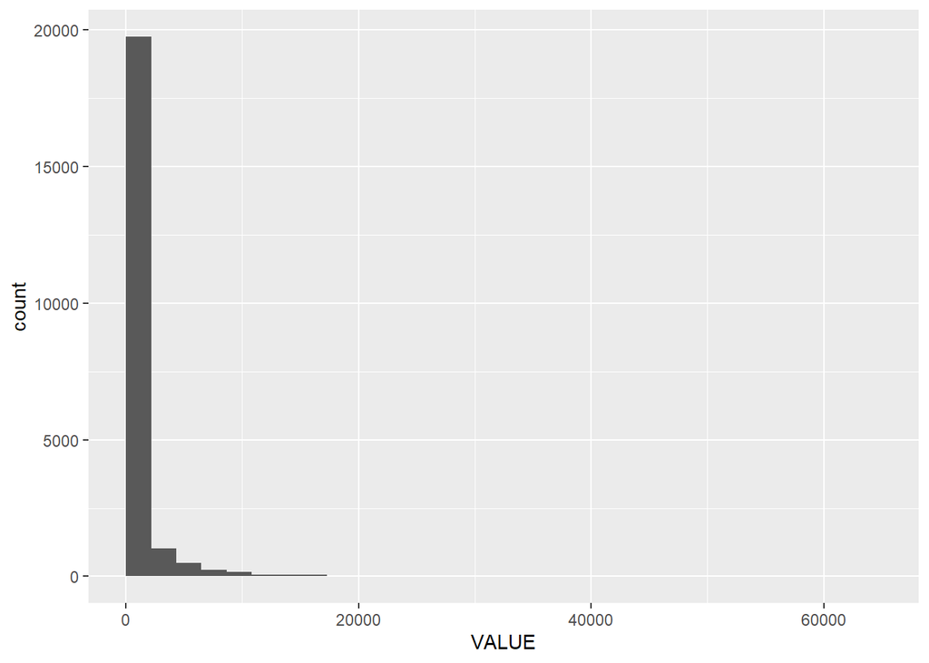

```r
# Create a histogram of the 'VALUE' column in the 'clean_data' data
ggplot(clean_data,aes(x=VALUE))+
  geom_histogram(boundary=0,bindwith = 2)
```

This shows the distribution of value(housing prices) variable, which is highly right-skewed. Most of the data are concentrated on the left side of the distribution. This points out that significant portion of the values in the dataset are small in value with few proportion been large.

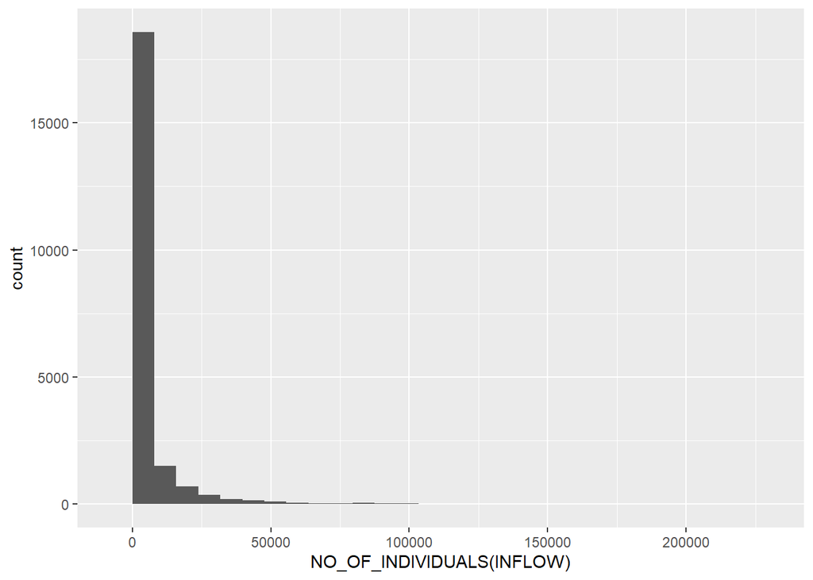

```r
# Create a histogram of the 'NO_OF_INDIVIDUALS(INFLOW)' column in the 'clean_data' data frame
ggplot(clean_data,aes(x=`NO_OF_INDIVIDUALS(INFLOW)`))+
  geom_histogram(boundary=0,bindwith = 2)
```

This shows the distribution of number of individual(inflow) i.e. migrantion variable, which highly right-skewed. Most of the data are concentrated on the left side of the distribution.

Applying log transformation to variables because they are right skewed.Applying the log will reduce the skewness, compressing the larger values and spreading out the smaller ones. This will better reflect the central tendency.

```r
# Apply log transformation to VALUE and NO_OF_INDIVIDUALS(INFLOW) to create new log-transformed variables
clean_data$LOG_VALUE = log(clean_data$VALUE + 1)
clean_data$LOG_MIGRATION = log(clean_data$`NO_OF_INDIVIDUALS(INFLOW)` + 1)
```

Creating the histogram graphs and other exploratory analysis using the log variables that we have created through transformation

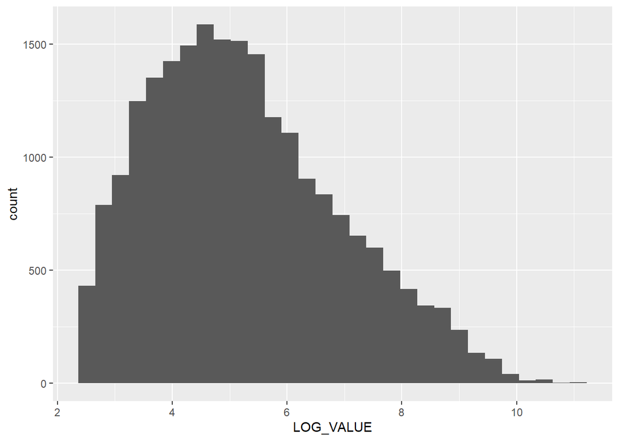

```r
# Create a histogram of the 'LOG_VALUE' column in the 'clean_data' data frame
ggplot(clean_data,aes(x=LOG_VALUE))+
  geom_histogram(boundary=0,bindwith = 0.5)
```

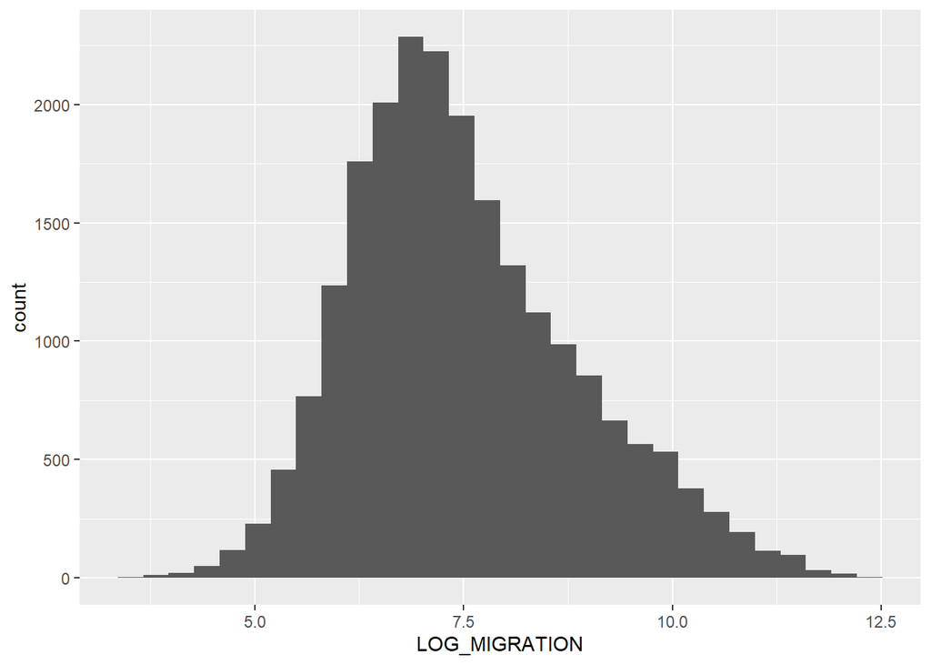

```r
# Create a histogram of the 'LOG_MIGRATION' column in the 'clean_data' data frame
ggplot(clean_data,aes(x=LOG_MIGRATION))+
  geom_histogram(boundary=0,bindwith = 0.5)
```

Finding the relationship between migration and housing prices

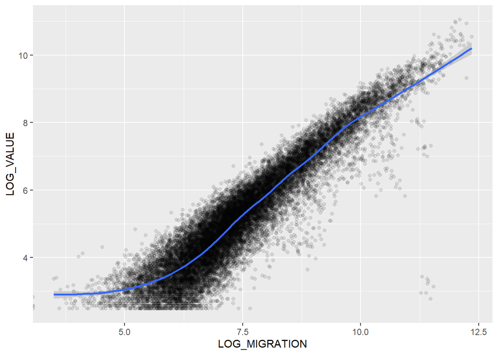

```r
# Create a scatter plot of LOG_MIGRATION vs. LOG_VALUE with a smoothing line
ggplot(clean_data, aes(x=LOG_MIGRATION, y =LOG_VALUE)) +
# Add points with low transparent
  geom_point(alpha = 0.1)+
# Add a smooth line to show trend
  geom_smooth()
```

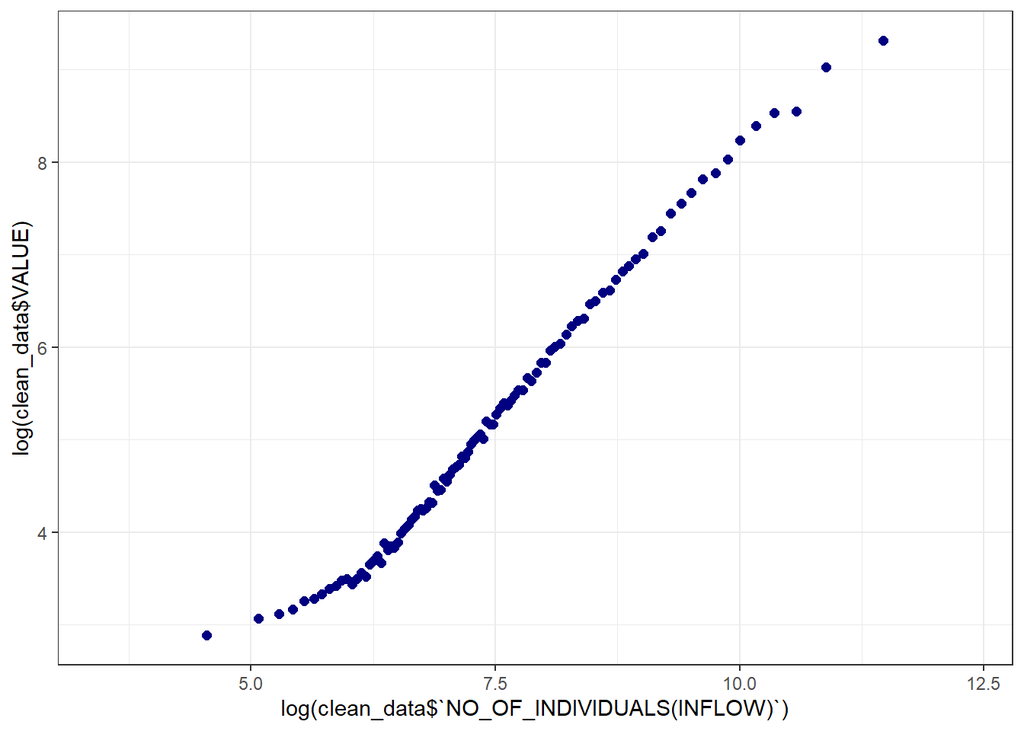

```
## Call: binsreg
##
## Binscatter Plot
## Bin/Degree selection method (binsmethod)  =  IMSE direct plug-in (select # of bins)
## Placement (binspos)                       =  Quantile-spaced
## Derivative (deriv)                        =  0
##
## Group (by)                         =  Full Sample
## Sample size (n)                    =  21893
## # of distinct values (Ndist)       =  8403
## # of clusters (Nclust)             =  NA
## dots, degree (p)                   =  0
## dots, smoothness (s)               =  0
## # of bins (nbins)                  =  98
```

```r
#Generate a binned scatter plot of log-transformed VALUE and log-transformed NO_OF_INDIVIDUALS(INFLOW)
binsreg(log(clean_data$VALUE),log(clean_data$`NO_OF_INDIVIDUALS(INFLOW)`))
```

There is an overall positive relationship between immigration and housing prices, as indicated by the upward trend. As the NO_OF_INDIVIDUALS(INFLOW) increases, VALUE also tends to increase, suggesting a direct association(correlation) between these two variables. This also affirms the relationship between the variables by the scatter graph even though this show a non - linear relationship